# Health and Economic Effects of Storm Events

Jim White

October 21, 2015

### Synopsis

This report makes use of a dataset from the National Weather Service & National Climatic Data Center Storm Events. The construction and definition of the variables in the data can be found at Storm Data Documentation and FAQs from the Climatic Data Center. The purpose of this analysis was to determine the weather events that have the most effect on health (fatalities and injuries) and economy (property and crop damage). The event types having the greates impact on fatalities for the period between 1996 and 2011 were excessive heat, tornados, and flash floods. The greatest number of injuries are due to tornados. Not surprisingly, hail creates the greatest amount of economic loss for crops, followed by flooding. The largest contributors to property loss are thunderstorm winds, flooding, and tornados.

### Loading and Processing the Data

The variables included in the transformed dataset are:

```
1. EVTYPE - type of meterological event (48 different types available)
2. END_DATE - the end date of the event
3. FATALITIES - the number of deaths related to the event (individuals)
4. INJURIES - the number of injuries related to the event (individuals)
5. PROPDMG - estimated amount of damage to property due to the event (thousands of dollars)
6. CROPDMG - estimated amount of damage to crops due to the event (thousands of dollars)
```

**Requirements** This analysis requires the use of these packages: dplyr, gridExtra, ggplot2

Preliminaries - loading necessary libraries

```r
suppressMessages(library(dplyr))
library(gridExtra)
library(ggplot2)
```

**Data Processing** First download the file and load into R as activity_data variable. Only load those columns (variables) relative to answering the data analysis questions. This part of the process will takes a few minutes because of the size of the original data file.

```r
download.file("https://d396qusza40orc.cloudfront.net/repdata%2Fdata%2FStormData.csv.bz2", "stormData.bz2")
activity_data <- read.csv("StormData.bz2")[, c(8, 12, 23, 24, 25, 27)]
```

Transform EVTYPE & END_DATE variables to character and date types, respectively, and PROPDMG & CROPDMG to integer format

```r
activity_data$EVTYPE <- as.character(activity_data$EVTYPE)
activity_data$END_DATE <- as.Date(activity_data$END_DATE, "%m/%d/%Y ")
activity_data$PROPDMG <- as.integer(activity_data$PROPDMG)
activity_data$CROPDMG <- as.integer(activity_data$CROPDMG)
```

```r
activity_data_sub <- subset(activity_data, !is.na(END_DATE) & END_DATE > as.Date("1995-12-31"))
```

Group the dataset by the ENVTYPE variable and sum the fatalities, injuries, property, and crop damage variables to find the EVTYPES that create the greatest health and economic effects.

```r
# summarize and grouped by EVTYPE
summary_data <- activity_data_sub %>% group_by(EVTYPE) %>% summarize(fatal = sum(FATALITIES), injury = sum(INJURIES), propdmg = sum(PROPDMG), cropdmg = sum(CROPDMG))
```

Indentify dimensions of the summary data

```r
dim(summary_data)
```

```
## [1] 516   5
```

The 516 event types identified in the summary data set indicate that there are still event types that are miscoded.

Examine a summary of the data set

```r
summary(summary_data)
```

```
##     EVTYPE              fatal             injury
##  Length:516         Min.   :   0.00   Min.   :    0.0
##  Class :character   1st Qu.:   0.00   1st Qu.:    0.0
##  Mode  :character   Median :   0.00   Median :    0.0
##                     Mean   :  16.92   Mean   :  112.4
##                     3rd Qu.:   0.00   3rd Qu.:    0.0
##                     Max.   :1797.00   Max.   :20667.0
##     propdmg             cropdmg
##  Min.   :      0.0   Min.   :     0
##  1st Qu.:      0.0   1st Qu.:     0
##  Median :      0.0   Median :     0
##  Mean   :  14795.7   Mean   :  2328
##  3rd Qu.:     17.2   3rd Qu.:     0
##  Max.   :1328574.0   Max.   :498231
```

We see that three of the four variables have values of 0 (zero) through the 3rd quartile (75% of the event types). This indicates that many of the event types do not have any health of economic concerns associated with them.

Each of the four variables are subset as a preparation for providing charts.

```r
# subset fatalities and sort decreasing
fatal_events <- summary_data[, c(1, 2)]
# sort descending order and select top 15 types
fatal_events <- fatal_events[head(order(fatal_events$fatal, decreasing = TRUE), n = 15L),]

# subset injuries and sort decreasing
injury_events <- summary_data[, c(1, 3)]
# sort descending order and select top 15 types
injury_events <- injury_events[head(order(injury_events$injury, decreasing = TRUE), n = 15L),]

# subset property damage and sort decreasing
propdmg_events <- summary_data[, c(1, 4)]
# sort descending order and select top 15 types
propdmg_events <- propdmg_events[head(order(propdmg_events$propdmg, decreasing = TRUE), n = 15L),]

# subset crop damage and sort decreasing
cropdmg_events <- summary_data[, c(1, 5)]
# sort descending order and select top 15 types
cropdmg_events <- cropdmg_events[head(order(cropdmg_events$cropdmg, decreasing = TRUE), n = 15L),]
```

### Results Section

This section provides charts and tables indicating the EVTYPEs that create the greatest health and economic risk.

**Question 1** - Across the United States, which types of events (as indicated in the EVTYPE variable) are most harmful with respect to population health?

Figure 1. Charts of top 15 weather types and their health effects (fatalities & injuries)

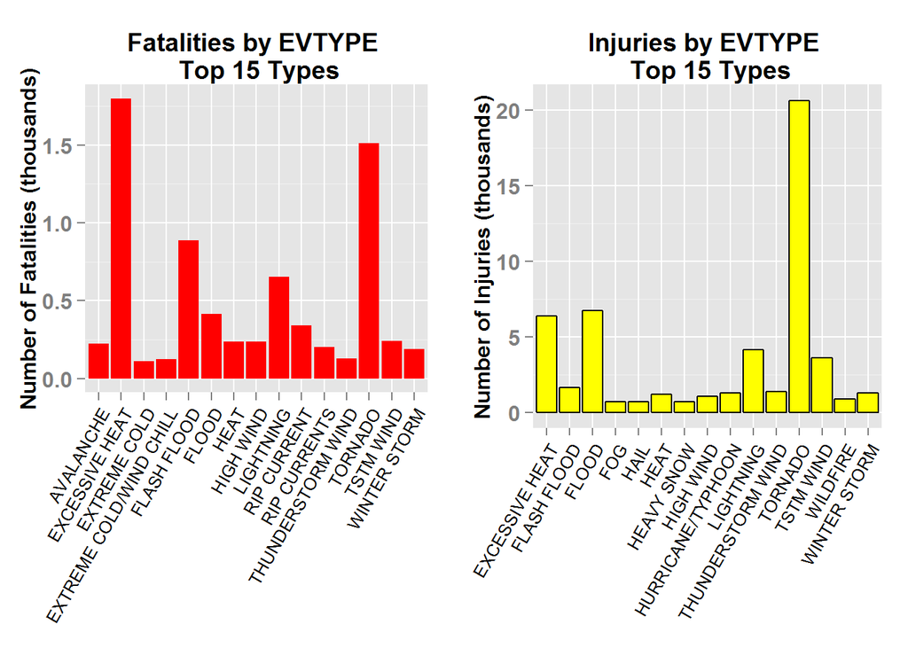

```r
# for fatalities
g1 <- ggplot(fatal_events, aes(EVTYPE, fatal/1000))
g1 <- g1 + geom_bar(stat = "identity", fill = "red")
g1 <- g1 + labs(title = "Fatalities by EVTYPE \n Top 15 Types")
g1 <- g1 + labs(y = "Number of Fatalities (thousands)")
g1 <- g1 + theme(plot.title = element_text(size = 14, face = "bold"),
               axis.title.x = element_blank(),
               axis.title.y = element_text(size = 12, face = "bold"),
               axis.text.x = element_text(colour = "black", angle = 60, hjust = 1),
               axis.text.y = element_text(size = 12, face = "bold"))

# for injuries
g2 <- ggplot(injury_events, aes(EVTYPE, injury/1000))
g2 <- g2 + geom_bar(stat = "identity", fill = "yellow", colour = "black")
g2 <- g2 + labs(title = "Injuries by EVTYPE \n Top 15 Types")
g2 <- g2 + labs(y = "Number of Injuries (thousands)")
g2 <- g2 + theme(plot.title = element_text(size = 14, face = "bold"),
               axis.title.x = element_blank(),
               axis.title.y = element_text(size = 12, face = "bold"),
               axis.text.x = element_text(colour = "black", angle = 60, hjust = 1),
               axis.text.y = element_text(size = 12, face = "bold"))

grid.arrange(g1, g2, ncol = 2)
```

As can be seen by examining Figure 1, the greatest number of fatalities occur during excessive heat events and the greatest number of injuries during tornado events (which is not surprising). A significant number of fatalities also occur due to flooding (represented by the types of “flash flood and flood”) and lightning. A list of the top event types and associated fatalities and injuries following the figure.

The top 15 event types for fatalities and injuries

```r
fatal_events
```

```
## Source: local data frame [15 x 2]
##
##                     EVTYPE fatal
##                      (chr) (dbl)
## 1           EXCESSIVE HEAT  1797
## 2                  TORNADO  1511
## 3              FLASH FLOOD   887
## 4                LIGHTNING   651
## 5                    FLOOD   414
## 6              RIP CURRENT   340
## 7                TSTM WIND   241
## 8                     HEAT   237
## 9                HIGH WIND   235
## 10               AVALANCHE   223
## 11            RIP CURRENTS   202
## 12            WINTER STORM   191
## 13       THUNDERSTORM WIND   130
## 14 EXTREME COLD/WIND CHILL   125
## 15            EXTREME COLD   113
```

```r
injury_events
```

```
## Source: local data frame [15 x 2]
##
##               EVTYPE injury
##                (chr)  (dbl)
## 1            TORNADO  20667
## 2              FLOOD   6758
## 3     EXCESSIVE HEAT   6391
## 4          LIGHTNING   4141
## 5          TSTM WIND   3629
## 6        FLASH FLOOD   1674
## 7  THUNDERSTORM WIND   1400
## 8       WINTER STORM   1292
## 9  HURRICANE/TYPHOON   1275
## 10              HEAT   1222
## 11         HIGH WIND   1083
## 12          WILDFIRE    911
## 13              HAIL    713
## 14               FOG    712
## 15        HEAVY SNOW    698
```

The top 15 event types for fatalities and injuries represent a significant amount of the totals from the activity_data_sub dataset. One concern when doing the analysis was that when the data was summarized by the EVTYPEs, 516 types emerged - many of these are due to misspellings for the EVTYPE variable.

The following calculates the 15 top event totals (for fatalities and injuries) compared to the totals for all records in the relelvant variables of the activity_date_sub dataset:

```r
x <- sum(fatal_events$fatal)/sum(activity_data_sub$FATALITIES)
paste("The top 15 event type fatalities as a percent of the total fatalities = ", round(x*100, 0), "%")
```

```
## [1] "The top 15 event type fatalities as a percent of the total fatalities =  84 %"
```

```r
y <- sum(injury_events$injury/sum(activity_data_sub$INJURIES))
paste("The top 15 event type injuries as a percent of the total injuries = ", round(y*100, 0), "%")
```

```
## [1] "The top 15 event type injuries as a percent of the total injuries =  91 %"
```

**Question 2** - Across the United States, which types of events have the greatest economic consequences?

Figure 2. Charts of top 15 weather types and their economic effects

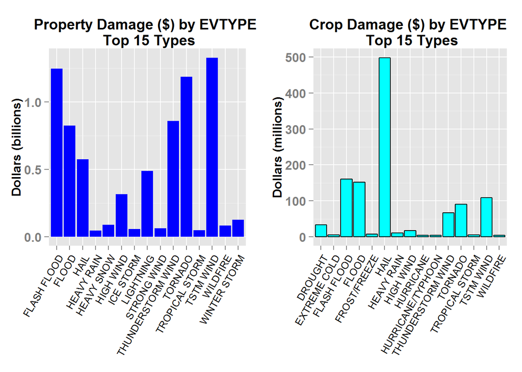

```r
# for property damage
g3 <- ggplot(head(propdmg_events, n = 15L), aes(EVTYPE, propdmg/1000000))
g3 <- g3 + geom_bar(stat = "identity", fill = "blue")
g3 <- g3 + labs(title = "Property Damage ($) by EVTYPE \n Top 15 Types")
g3 <- g3 + labs(y = "Dollars (billions)")
g3 <- g3 + theme(plot.title = element_text(size = 14, face = "bold"),
               axis.title.x = element_blank(),
               axis.title.y = element_text(size = 12, face = "bold"),
               axis.text.x = element_text(colour = "black", angle = 60, hjust = 1),
               axis.text.y = element_text(size = 12, face = "bold"))

# for crop damage
g4 <- ggplot(head(cropdmg_events, n = 15L), aes(EVTYPE, cropdmg/1000))
g4 <- g4 + geom_bar(stat = "identity", fill = "cyan", colour = "black")
g4 <- g4 + labs(title = "Crop Damage ($) by EVTYPE \n Top 15 Types")
g4 <- g4 + labs(y = "Dollars (millions)")
g4 <- g4 + theme(plot.title = element_text(size = 14, face = "bold"),
               axis.title.x = element_blank(),
               axis.title.y = element_text(size = 12, face = "bold"),
               axis.text.x = element_text(colour = "black", angle = 60, hjust = 1),
               axis.text.y = element_text(size = 12, face = "bold"))

grid.arrange(g3, g4, ncol = 2)
```

The top 15 event types for economic loss

```r
propdmg_events
```

```
## Source: local data frame [15 x 2]
##
##               EVTYPE propdmg
##                (chr)   (int)
## 1          TSTM WIND 1328574
## 2        FLASH FLOOD 1247227
## 3            TORNADO 1187540
## 4  THUNDERSTORM WIND  860406
## 5              FLOOD  824577
## 6               HAIL  574624
## 7          LIGHTNING  488378
## 8          HIGH WIND  314910
## 9       WINTER STORM  126868
## 10        HEAVY SNOW   89367
## 11          WILDFIRE   82955
## 12       STRONG WIND   62339
## 13         ICE STORM   57941
## 14    TROPICAL STORM   47770
## 15        HEAVY RAIN   46982
```

```r
cropdmg_events
```

```
## Source: local data frame [15 x 2]
##
##               EVTYPE cropdmg
##                (chr)   (int)
## 1               HAIL  498231
## 2        FLASH FLOOD  161052
## 3              FLOOD  151800
## 4          TSTM WIND  109034
## 5            TORNADO   90110
## 6  THUNDERSTORM WIND   66663
## 7            DROUGHT   33271
## 8          HIGH WIND   17258
## 9         HEAVY RAIN   10964
## 10      FROST/FREEZE    7032
## 11      EXTREME COLD    5614
## 12    TROPICAL STORM    5259
## 13         HURRICANE    4836
## 14 HURRICANE/TYPHOON    4791
## 15          WILDFIRE    4360
```

The top 15 event types for economic effect represent a significant amount of the totals from the activity_data dataset (as with the health concerns)

The following calculates the 15 top event totals (for property and crop damages) compared to the totals for all records in the relelvant variables of the activity_data_sub dataset:

```r
z <- sum(propdmg_events$propdmg)/sum(activity_data_sub$PROPDMG)
paste("The top 15 event types related to property damage as a percent of the total property damage = ", round(z*100, 0), "%")
```

```
## [1] "The top 15 event types related to property damage as a percent of the total property damage =  96 %"
```

```r
w <- sum(cropdmg_events$cropdmg/sum(activity_data_sub$CROPDMG))
paste("The top 15 event types of related to crop damage as a percent of the total crop damages = ", round(w*100, 0), "%")
```

```
## [1] "The top 15 event types of related to crop damage as a percent of the total crop damages =  97 %"
```

The 15 top events represent 96% of the property damage (dollars) and 97% of the crop damage (dollars) in the activity_data_sub dataset.